# Spotify Songs Popularity Prediction

I aim to use regression to determine which values influence the popularity of songs listened to on Spotify. First, I would like to discuss my dataset.

```
names(data)
```

```
 [1] "artist"           "song"             "duration_ms"      "explicit"
 [5] "year"             "popularity"       "danceability"     "energy"
 [9] "key"              "loudness"         "mode"             "speechiness"
[13] "acousticness"     "instrumentalness" "liveness"         "valence"
[17] "tempo"            "genre"
```

I imported the dataset using the read.csv() function and stored it in the variable data. I did this so I could use the yield.After that , names(data) showed us column of the data.Then, I listed all column names using names(data). From here, we will determine our dependent and independent variables. My goal is to find out what factors influence popularity, so my dependent variable is popularity, and I can treat the other variables as independent.

```
df<-data[-c(1,2,4,5,9,18)]
names(df)
```

```
 [1] "duration_ms"      "popularity"       "danceability"     "energy"
 [5] "loudness"         "mode"             "speechiness"      "acousticness"
 [9] "instrumentalness" "liveness"         "valence"          "tempo"
```

At this point, I selected the variables to include in my model.I created a new data frame by removing the column numbers of the variables I didn’t want using in model.Now, I want to find the relationship between my variables.However, only numerical values should be used with the cor() function, otherwise it will return an error.

```
numeric_df <- df[sapply(df, is.numeric)]
df_cor<-cor(numeric_df)
df_cor
```

```
                  duration_ms   popularity danceability      energy    loudness
duration_ms       1.000000000  0.050617219  -0.06005683 -0.07876307 -0.07991182
popularity        0.050617219  1.000000000  -0.00354573 -0.01402125  0.03063232
danceability     -0.060056831 -0.003545730   1.00000000 -0.10403836 -0.03331486
energy           -0.078763069 -0.014021252  -0.10403836  1.00000000  0.65101552
loudness         -0.079911825  0.030632316  -0.03331486  0.65101552  1.00000000
mode             -0.003847828 -0.021353361  -0.06752847 -0.04065103 -0.02813256
speechiness       0.066997560  0.021162353   0.14558969 -0.05701819 -0.07638819
acousticness      0.010923427  0.024619168  -0.06542889 -0.44546852 -0.31003918
instrumentalness -0.004207880 -0.048059226   0.02320731  0.03786112 -0.10492465
liveness          0.024940765 -0.009855757  -0.12641287  0.15676071  0.10215898
valence          -0.116869842 -0.016142058   0.40317765  0.33447443  0.23215045
tempo            -0.028602813  0.014288465  -0.17341799  0.15371909  0.08070880
                          mode   speechiness  acousticness instrumentalness
duration_ms      -3.847828e-03  6.699756e-02  0.0109234265      -0.00420788
popularity       -2.135336e-02  2.116235e-02  0.0246191679      -0.04805923
danceability     -6.752847e-02  1.455897e-01 -0.0654288929       0.02320731
energy           -4.065103e-02 -5.701819e-02 -0.4454685177       0.03786112
loudness         -2.813256e-02 -7.638819e-02 -0.3100391798      -0.10492465
mode              1.000000e+00 -7.683285e-05  0.0057444752      -0.03861291
speechiness      -7.683285e-05  1.000000e+00  0.0003941595      -0.06295384
acousticness      5.744475e-03  3.941595e-04  1.0000000000      -0.00521442
instrumentalness -3.861291e-02 -6.295384e-02 -0.0052144202       1.00000000
liveness          2.543871e-02  6.117214e-02 -0.1100430562      -0.03489654
valence          -7.468090e-02  7.360500e-02 -0.1281278858      -0.01519150
tempo             4.843437e-02  5.774747e-02 -0.1036599909       0.03460754
                     liveness     valence       tempo
duration_ms       0.024940765 -0.11686984 -0.02860281
popularity       -0.009855757 -0.01614206  0.01428847
danceability     -0.126412872  0.40317765 -0.17341799
energy            0.156760713  0.33447443  0.15371909
loudness          0.102158983  0.23215045  0.08070880
mode              0.025438707 -0.07468090  0.04843437
speechiness       0.061172138  0.07360500  0.05774747
acousticness     -0.110043056 -0.12812789 -0.10365999
instrumentalness -0.034896542 -0.01519150  0.03460754
liveness          1.000000000  0.01903963  0.02863569
valence           0.019039631  1.00000000 -0.02507583
tempo             0.028635693 -0.02507583  1.00000000
```

If the result is positive, there is an effect in the same direction. But if it is negative, there is an effect in the opposite direction. That is, when one increases, the other decreases.

```
heatmap(df_cor)
```

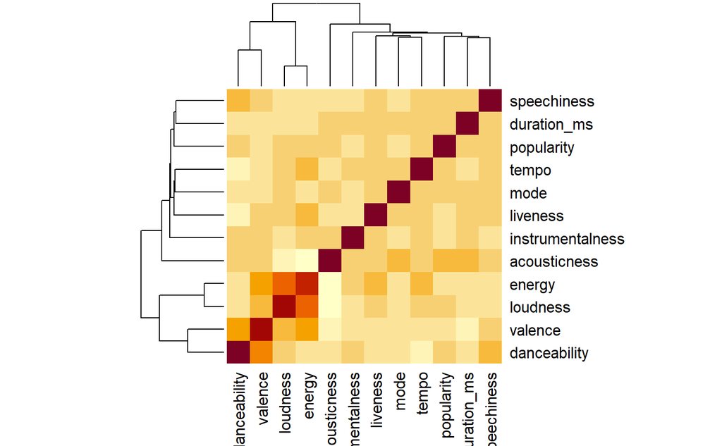

```
pop_cor<-cor(numeric_df)[,"popularity"]
barplot(pop_cor)
```

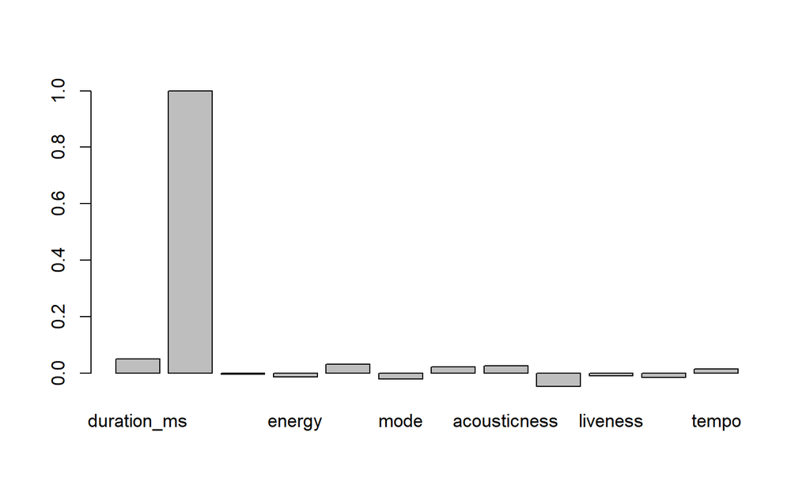

Since we want the bar chart showing the relationship between popularity and the others, we first need to select popularity and assign its correlation to a variable. We did this in the first line; in the second line, we draw the bar chart.Now, it is time to create a model.

```
model<-lm(popularity~duration_ms + danceability+energy+
            loudness+mode+speechiness+acousticness+instrumentalness,data=numeric_df)
```

We created our first model.

```
summary(model)
```

```
Call:
lm(formula = popularity ~ duration_ms + danceability + energy +
    loudness + mode + speechiness + acousticness + instrumentalness,
    data = numeric_df)

Residuals:
    Min      1Q  Median      3Q     Max
-63.075  -3.764   5.419  13.465  30.094

Coefficients:
                   Estimate Std. Error t value Pr(>|t|)
(Intercept)       6.175e+01  6.339e+00   9.740   <2e-16 ***
duration_ms       2.763e-05  1.228e-05   2.250   0.0246 *
danceability     -6.188e-01  3.499e+00  -0.177   0.8597
energy           -5.520e+00  4.462e+00  -1.237   0.2162
loudness          7.185e-01  3.308e-01   2.172   0.0299 *
mode             -9.810e-01  9.617e-01  -1.020   0.3078
speechiness       4.130e+00  5.046e+00   0.818   0.4132
acousticness      3.237e+00  3.096e+00   1.046   0.2959
instrumentalness -9.479e+00  5.533e+00  -1.713   0.0868 .
---
Signif. codes:  0 ‘***’ 0.001 ‘**’ 0.01 ‘*’ 0.05 ‘.’ 0.1 ‘ ’ 1

Residual standard error: 21.29 on 1991 degrees of freedom
Multiple R-squared:  0.008532,  Adjusted R-squared:  0.004548
F-statistic: 2.142 on 8 and 1991 DF,  p-value: 0.02922
```

We can access all information about our model using the summary function. Residuals are the difference between the observed value and the value predicted by the model. Coefficients are the coefficients found in the linear regression equation. They determine the relationship. Multiple R-squared is a statistic that shows how much of the variance in the dependent variable is explained by the independent variables in the model. Our value being very low indicates that our model is poor. However, we had already observed with the cor() function that the relationship between popularity and the other variables was very low.Now , it is time to see plots.

```
plot(model)
```

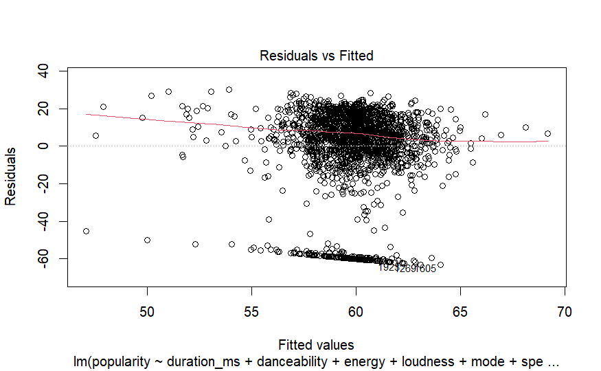

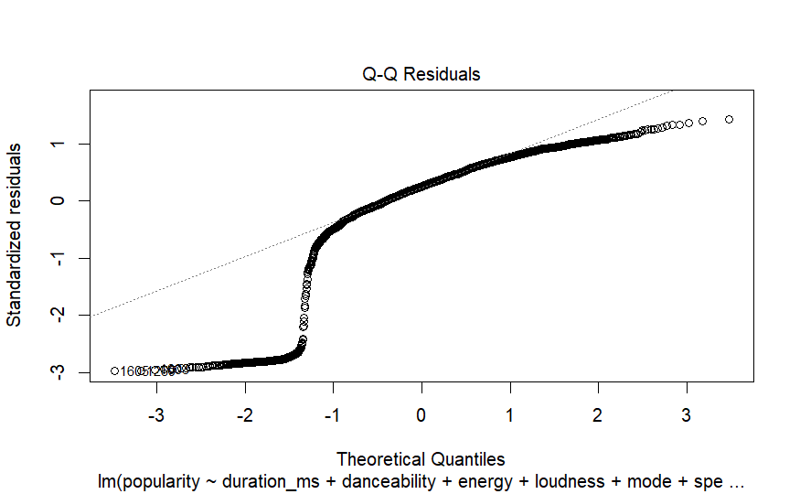

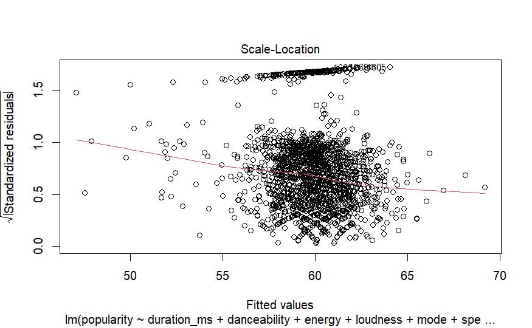

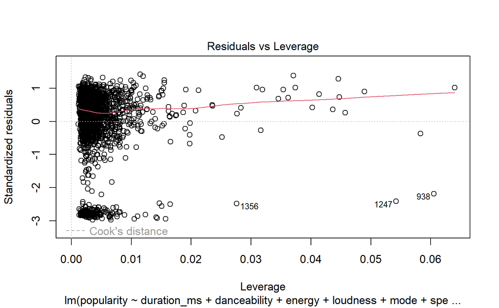

Residuals vs Fitted

Shows if residuals are randomly distributed. A random scatter means the model fits well.

Normal Q-Q

Scale-Location

Tests if variance of residuals is constant. A flat red line means equal variance — a good sign.

Residuals vs Leverage

Detects influential or outlier points. Points outside red lines may strongly affect the model.

It’s time to split the data. Typically, 80% of the data is used for training and 20% for testing. There’s no particular reason for this.But before creating random data, we should use set.seed(). That will protect first random data.

```
set.seed(6)
traindIndex<-sample(1:nrow(numeric_df),size=0.8*nrow(numeric_df))
traindata<-numeric_df[traindIndex,]
testdata<-numeric_df[-traindIndex,]
```

We have created our train and test data.

```
vif(model)
```

```
     duration_ms     danceability           energy         loudness
        1.018984         1.064883         2.048945         1.804254
            mode      speechiness     acousticness instrumentalness
        1.008913         1.038564         1.270971         1.040398
```

In conclusion, the model shows that the relationships between popularity and other variables are weak. Still, since the R² value remains low, we can infer that song popularity depends on other external factors beyond the given dataset, such as marketing or artist recognition.